# Laboratorium: modele inferencyjne - rozwiązania

Bootstrap i testy permutacyjne

Author

Dariusz Majerek

## Zadanie 1. Hipoteza parametryczna jednopróbkowa

Badamy, czy przeciętny tygodniowy czas pracy przekracza 40 godzin. Statystyką testową będzie średnia z próby.

$$\begin{align}
H_0: \mu &= 40\\
H_1: \mu &> 40
\end{align}$$

### Krok 1. Przygotowanie danych i statystyka obserwowana

Usuwamy braki danych i liczymy średnią z próby.

```r
hours_data <- gss %>%
  drop_na(hours)

observed_mean <- hours_data %>%
  specify(response = hours) %>%
  calculate(stat = "mean")

observed_mean
```

```
Response: hours (numeric)
# A tibble: 1 × 1
   stat
  <dbl>
1  41.4
```

### Krok 2. Rozkład bootstrapowy zgodny z `H_0`

W teście bootstrapowym dla hipotezy punktowej pakiet `infer` buduje rozkład zgodny z `H_0`, a następnie losuje z niego próby bootstrapowe.

```r
set.seed(2026)

null_boot_mean <- hours_data %>%
  specify(response = hours) %>%
  hypothesize(null = "point", mu = 40) %>%
  generate(reps = 2000, type = "bootstrap") %>%
  calculate(stat = "mean")

null_boot_mean
```

```
Response: hours (numeric)
Null Hypothesis: point
# A tibble: 2,000 × 2
   replicate  stat
       <int> <dbl>
 1         1  40.6
 2         2  41.0
 3         3  40.9
 4         4  40.2
 5         5  40.0
 6         6  39.1
 7         7  40.3
 8         8  39.8
 9         9  40.1
10        10  41.0
# ℹ 1,990 more rows
```

### Krok 3. Wizualizacja i wartość `p`

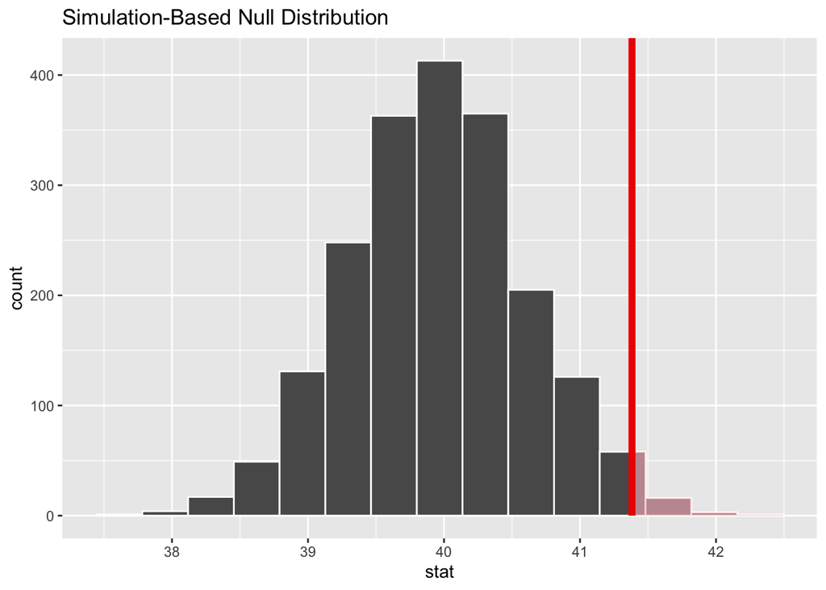

```r
null_boot_mean %>%
  visualize() +
  shade_p_value(obs_stat = observed_mean, direction = "greater")
```

```r
p_value_mean <- null_boot_mean %>%
  get_p_value(obs_stat = observed_mean, direction = "greater")

p_value_mean
```

```
# A tibble: 1 × 1
  p_value
    <dbl>
1  0.0155
```

Otrzymujemy wartość `p` około `0.016`, więc przy poziomie istotności `0.05` odrzucamy hipotezę zerową. Dane sugerują, że średni tygodniowy czas pracy jest większy niż 40 godzin.

### Krok 4. Porównanie z testem klasycznym

```r
t.test(hours_data$hours, mu = 40, alternative = "greater")
```

```
    One Sample t-test

data:  hours_data$hours
t = 2.0852, df = 499, p-value = 0.01878
alternative hypothesis: true mean is greater than 40
95 percent confidence interval:
 40.28981      Inf
sample estimates:
mean of x
   41.382
```

Wynik klasycznego testu `t` jest bardzo podobny, więc oba podejścia prowadzą do tego samego wniosku.

## Zadanie 2. Hipoteza parametryczna dwupróbkowa

Porównujemy średnią długość zębów pomiędzy grupami `OJ` i `VC`. Statystyką testową jest różnica średnich.

$$\begin{align}
H_0: \mu_{OJ} &= \mu_{VC}\\
H_1: \mu_{OJ} &\neq \mu_{VC}
\end{align}$$

### Krok 1. Statystyka obserwowana

```r
observed_diff_mean <- ToothGrowth %>%
  specify(len ~ supp) %>%
  calculate(stat = "diff in means", order = c("OJ", "VC"))

observed_diff_mean
```

```
Response: len (numeric)
Explanatory: supp (factor)
# A tibble: 1 × 1
   stat
  <dbl>
1   3.7
```

Otrzymana wartość dodatnia oznacza, że w próbie średnia dla `OJ` jest większa niż dla `VC`.

### Krok 2. Rozkład permutacyjny pod `H_0`

Jeśli `H_0` jest prawdziwa, to etykiety grup można losowo przestawiać bez zmiany rozkładu danych. To właśnie robi test permutacyjny.

```r
set.seed(2026)

null_perm_mean <- ToothGrowth %>%
  specify(len ~ supp) %>%
  hypothesize(null = "independence") %>%
  generate(reps = 2000, type = "permute") %>%
  calculate(stat = "diff in means", order = c("OJ", "VC"))

null_perm_mean
```

```
Response: len (numeric)
Explanatory: supp (factor)
Null Hypothesis: independence
# A tibble: 2,000 × 2
   replicate   stat
       <int>  <dbl>
 1         1  1.73
 2         2  0.167
 3         3  0.360
 4         4 -2.59
 5         5  0.407
 6         6 -0.207
 7         7 -2.25
 8         8  4.52
 9         9  1.59
10        10  0.527
# ℹ 1,990 more rows
```

### Krok 3. Wizualizacja i wartość `p`

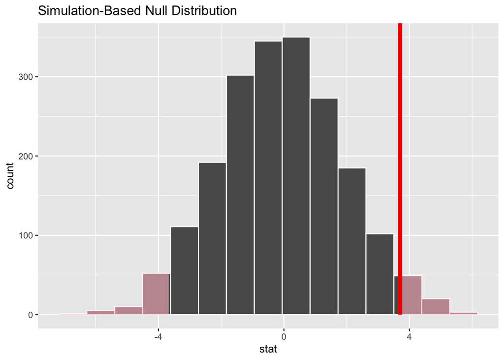

```r
null_perm_mean %>%
  visualize() +
  shade_p_value(obs_stat = observed_diff_mean, direction = "two-sided")
```

```r
p_value_diff_mean <- null_perm_mean %>%
  get_p_value(obs_stat = observed_diff_mean, direction = "two-sided")

p_value_diff_mean
```

```
# A tibble: 1 × 1
  p_value
    <dbl>
1   0.063
```

Wartość `p` jest bliska `0.05`, ale w tej konfiguracji pozostaje nieco powyżej tego progu. To oznacza, że wynik jest graniczny, lecz formalnie nie daje jednoznacznych podstaw do odrzucenia `H_0` na poziomie istotności `0.05`.

### Krok 4. Porównanie z testem klasycznym

```r
t.test(len ~ supp, data = ToothGrowth)
```

```
    Welch Two Sample t-test

data:  len by supp
t = 1.9153, df = 55.309, p-value = 0.06063
alternative hypothesis: true difference in means between group OJ and group VC is not equal to 0
95 percent confidence interval:
 -0.1710156  7.5710156
sample estimates:
mean in group OJ mean in group VC
        20.66333         16.96333
```

Klasyczny test `t` daje bardzo podobny wynik, więc także tutaj oba podejścia są zgodne interpretacyjnie.

## Zadanie 3. Hipoteza nieparametryczna jednopróbkowa

Badamy medianę czasu oczekiwania na kolejny wybuch gejzeru Old Faithful. Ponieważ rozkład zmiennej `waiting` nie jest symetryczny, bardziej naturalnym parametrem położenia jest mediana.

$$\begin{align}
H_0: m &= 75\\
H_1: m &\neq 75
\end{align}$$

### Krok 1. Wstępna ocena danych

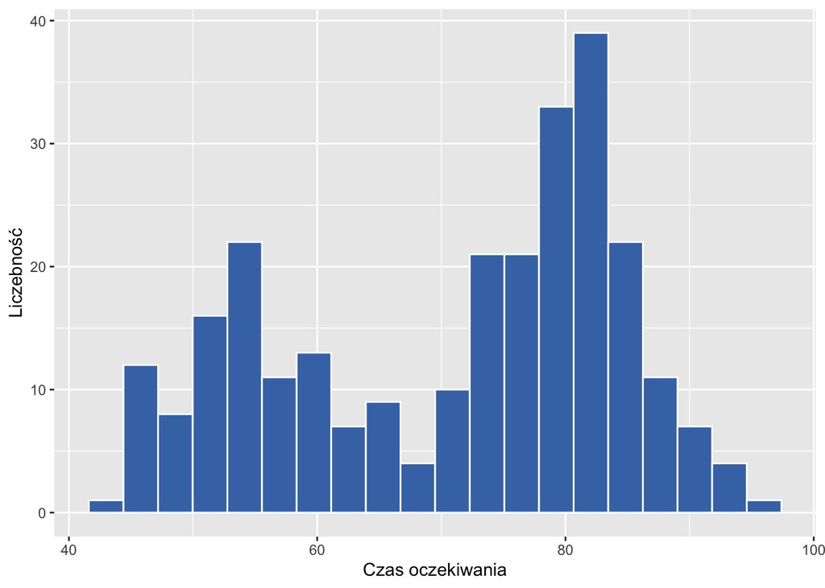

```r
faithful %>%
  ggplot(aes(waiting)) +
  geom_histogram(bins = 20, color = "white", fill = "#4575b4") +
  labs(x = "Czas oczekiwania", y = "Liczebność")
```

Histogram pokazuje wyraźnie, że rozkład nie ma prostego, normalnego kształtu. To dobry powód, aby oprzeć wnioskowanie o medianę na bootstrapie.

### Krok 2. Statystyka obserwowana

```r
observed_median <- faithful %>%
  specify(response = waiting) %>%
  calculate(stat = "median")

observed_median
```

```
Response: waiting (numeric)
# A tibble: 1 × 1
   stat
  <dbl>
1    76
```

Mediana próbki wynosi `76`, czyli jest blisko wartości z hipotezy zerowej.

### Krok 3. Rozkład bootstrapowy pod `H_0`

Pakiet `infer` pozwala bezpośrednio zadać hipotezę punktową dla mediany.

```r
set.seed(2026)

null_boot_median <- faithful %>%
  specify(response = waiting) %>%
  hypothesize(null = "point", med = 75) %>%
  generate(reps = 2000, type = "bootstrap") %>%
  calculate(stat = "median")

null_boot_median
```

```
Response: waiting (numeric)
Null Hypothesis: point
# A tibble: 2,000 × 2
   replicate  stat
       <int> <dbl>
 1         1  74
 2         2  75
 3         3  75
 4         4  74
 5         5  76
 6         6  75
 7         7  75
 8         8  73.5
 9         9  76
10        10  74
# ℹ 1,990 more rows
```

### Krok 4. Wizualizacja i wartość `p`

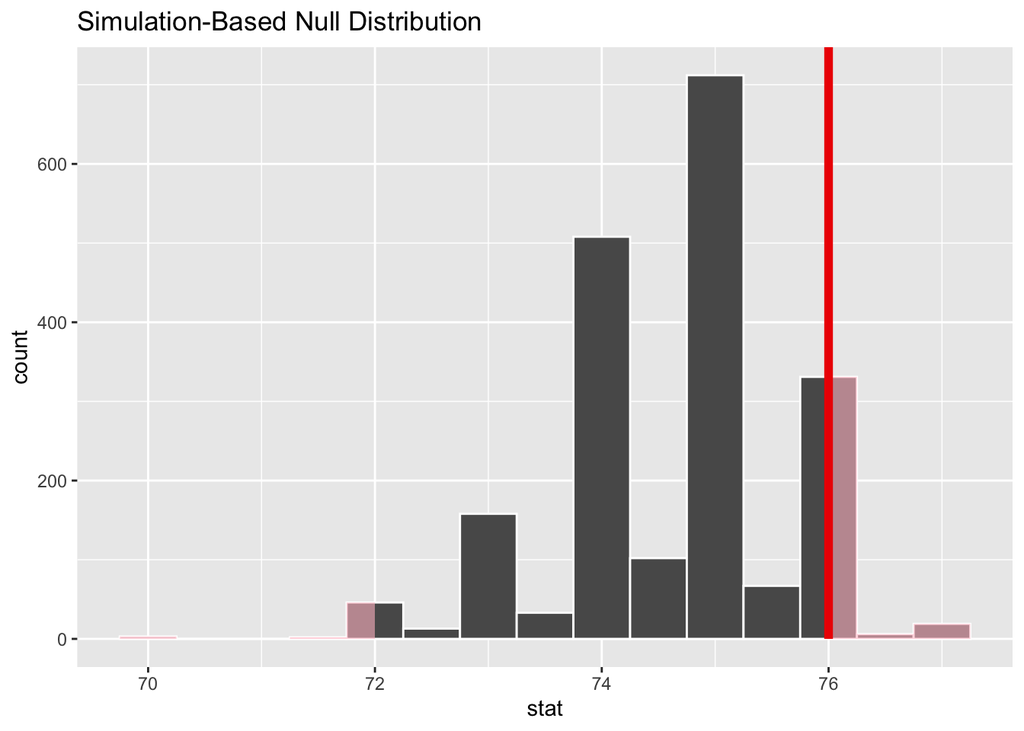

```r
null_boot_median %>%
  visualize() +
  shade_p_value(obs_stat = observed_median, direction = "two-sided")
```

```r
p_value_median <- null_boot_median %>%
  get_p_value(obs_stat = observed_median, direction = "two-sided")

p_value_median
```

```
# A tibble: 1 × 1
  p_value
    <dbl>
1   0.356
```

Wartość `p` jest wyraźnie większa od `0.05`, więc nie mamy podstaw do odrzucenia `H_0`. Dane są zgodne z hipotezą, że mediana czasu oczekiwania może wynosić 75 minut.

### Krok 5. Przedział ufności dla mediany

Wyznaczymy jeszcze klasyczny bootstrapowy przedział ufności dla mediany, tym razem bez narzucania hipotezy zerowej.

```r
set.seed(2026)

boot_median_ci <- faithful %>%
  specify(response = waiting) %>%
  generate(reps = 2000, type = "bootstrap") %>%
  calculate(stat = "median")

ci_median <- boot_median_ci %>%
  get_confidence_interval(
    point_estimate = observed_median,
    level = 0.95,
    type = "percentile"
  )

ci_median
```

```
# A tibble: 1 × 2
  lower_ci upper_ci
     <dbl>    <dbl>
1       73       77
```

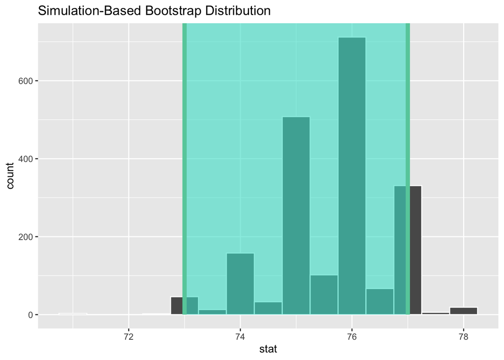

```r
boot_median_ci %>%
  visualize() +
  shade_ci(endpoints = ci_median)
```

Jeżeli wartość `75` należy do przedziału ufności, to wniosek jest zgodny z testem: brak podstaw do odrzucenia hipotezy zerowej.

## Zadanie 4. Hipoteza nieparametryczna dla zależności dwóch zmiennych ilościowych

Badamy, czy większa prędkość samochodu wiąże się z dłuższą drogą hamowania. Interesuje nas współczynnik kierunkowy prostej regresji.

$$\begin{align}
H_0: \beta_1 &= 0\\
H_1: \beta_1 &> 0
\end{align}$$

### Krok 1. Wizualizacja zależności

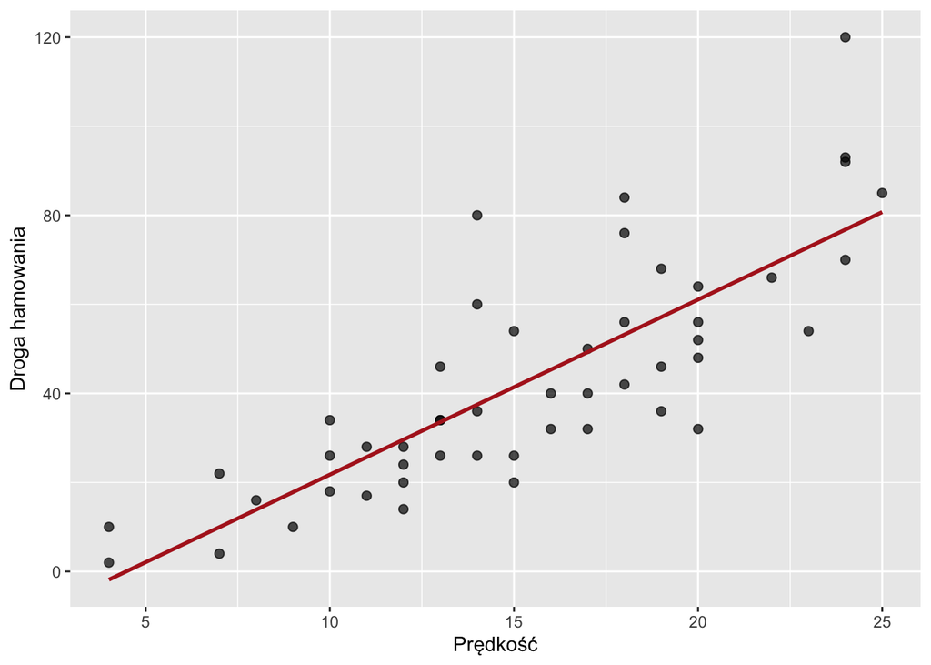

```r
cars %>%
  ggplot(aes(speed, dist)) +
  geom_point(size = 2, alpha = 0.7) +
  geom_smooth(method = "lm", se = FALSE, color = "firebrick") +
  labs(x = "Prędkość", y = "Droga hamowania")
```

Już na wykresie widać dodatnią zależność, ale teraz chcemy ocenić ją formalnie przez test permutacyjny.

### Krok 2. Nachylenie prostej w danych obserwowanych

```r
observed_slope <- cars %>%
  specify(dist ~ speed) %>%
  calculate(stat = "slope")

observed_slope
```

```
Response: dist (numeric)
Explanatory: speed (numeric)
# A tibble: 1 × 1
   stat
  <dbl>
1  3.93
```

Otrzymane nachylenie jest dodatnie, czyli wraz ze wzrostem prędkości droga hamowania rośnie.

### Krok 3. Permutacyjny rozkład nachyleń pod `H_0`

Jeśli `H_0` jest prawdziwa, to zmienna `dist` nie powinna być powiązana z `speed`. Możemy więc permutować wartości `dist` względem `speed`.

```r
set.seed(2026)

null_perm_slope <- cars %>%
  specify(dist ~ speed) %>%
  hypothesize(null = "independence") %>%
  generate(reps = 2000, type = "permute") %>%
  calculate(stat = "slope")

null_perm_slope
```

[output not shown]

### Krok 4. Wizualizacja i wartość `p`

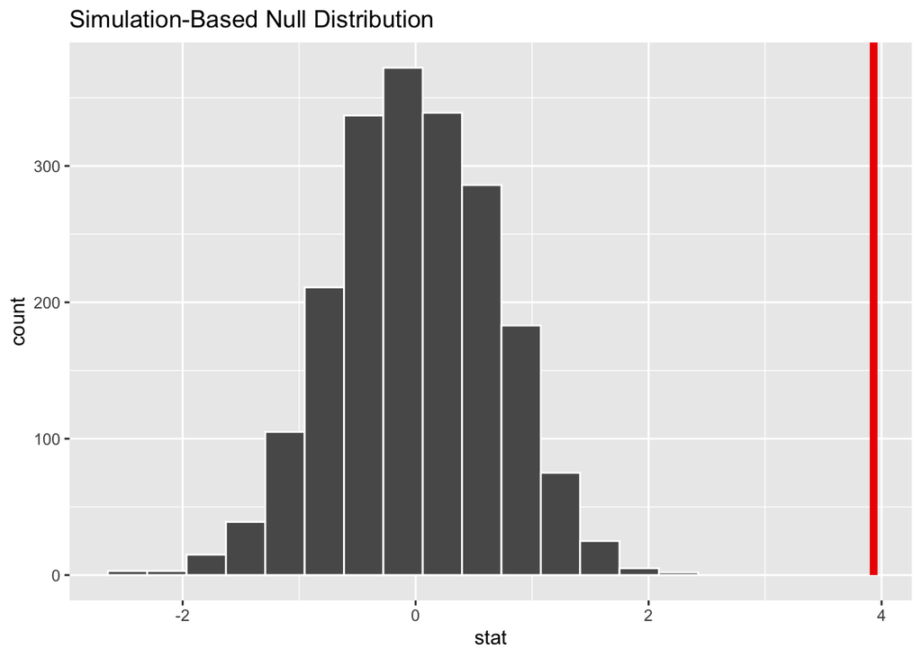

```r
null_perm_slope %>%
  visualize() +
  shade_p_value(obs_stat = observed_slope, direction = "greater")
```

```r
p_value_slope <- null_perm_slope %>%
  get_p_value(obs_stat = observed_slope, direction = "greater")

p_value_slope
```

```
# A tibble: 1 × 1
  p_value
    <dbl>
1       0
```

Otrzymujemy bardzo małą wartość `p`. Przy `2000` permutacjach wynik `0` oznacza w praktyce `p < 0.0005`, więc zdecydowanie odrzucamy `H_0`.

### Krok 5. Porównanie z klasycznym modelem liniowym

```r
summary(lm(dist ~ speed, data = cars))
```

```
Call:
lm(formula = dist ~ speed, data = cars)

Residuals:
    Min      1Q  Median      3Q     Max
-29.069  -9.525  -2.272   9.215  43.201

Coefficients:
            Estimate Std. Error t value Pr(>|t|)
(Intercept) -17.5791     6.7584  -2.601   0.0123 *
speed         3.9324     0.4155   9.464 1.49e-12 ***
---
Signif. codes:  0 '***' 0.001 '**' 0.01 '*' 0.05 '.' 0.1 ' ' 1

Residual standard error: 15.38 on 48 degrees of freedom
Multiple R-squared:  0.6511,    Adjusted R-squared:  0.6438
F-statistic: 89.57 on 1 and 48 DF,  p-value: 1.49e-12
```

Klasyczny model liniowy prowadzi do tego samego wniosku: współczynnik kierunkowy jest dodatni i istotny statystycznie. Test permutacyjny stanowi tu atrakcyjną alternatywę, ponieważ nie wymaga przyjmowania teoretycznego rozkładu statystyki testowej.